# Conditional Probability and Bayes’ Theorem

Zichao Liang zliang14 117122244

# 1 Simulating the Monty-Hall Problem

An interesting application of conditional probability is the Monty-Hall problem, whose solution intrigued many, including career mathematicians (life is hard!). There is a lot of trivia around this problem in the internet, a good place to start would be the Wikipedia article here: https://en.wikipedia.org/wiki/Monty_Hall_problem

In this project we will understand the solution of this problem using simulations.

## 1.1 Monty-Hall Three doors

Run a simulation to check that the probablility of winning increases to 2/3 if we switch doors at step two in the regular 3-door Monty-Hall problem.

Set up the experiment two functions “monty_3doors_noswitch” and “monty_3doors_switch” (these functions will have no input values):

```r
monty_3doors_noswitch <- function(){
  threedoors= seq(1,3)
  youpick = sample(threedoors, 1)
  prizedoor = sample(threedoors, 1)
  bool=0
  if(youpick==prizedoor){
    bool=1
  }
  bool
}

monty_3doors_switch <- function(){
  threedoors= seq(1,3)
  youpick = sample(threedoors, 1)
  prizedoor = sample(threedoors, 1)
  bool=0
  if(youpick!=prizedoor){
    bool=1
  }
  bool
}
```

Use your two functions and the replicate function to compute the empirical probablility of winning for the two experiments. Compare your answers with the actual theoretical predictions.

```r
winnumberns = replicate(1000, monty_3doors_noswitch());
probns = sum(winnumberns)/1000
paste0(probns, " vs 0.33333")
```

```
## [1] "0.347 vs 0.33333"
```

```r
winnumbers = replicate(1000, monty_3doors_switch());
probs = sum(winnumbers)/1000
paste0(probs, " vs 0.66667")
```

```
## [1] "0.669 vs 0.66667"
```

## 1.2 Monty-Hall with Ten doors.

Repeat the Monty Hall experiment now with 10 doors. Recall the game is as follows: Step 1: you choose one door at random. Step 2: Monty opens 8 (out of 9 doors) that do not have the prize. Step 3: you either switch or don’t switch.

Set up the experiment two functions “monty_10doors_noswitch” and “monty_10doors_switch” (these functions will have no input values):

```r
monty_10doors_noswitch <- function(){
  tendoor= seq(1,10)
  youpick = sample(tendoor, 1)
  prizedoor = sample(tendoor, 1)
  bool=0
  if(youpick==prizedoor){
    bool=1
  }
  bool
}

monty_10doors_switch <- function(){
  tendoor= seq(1,10)
  youpick = sample(tendoor, 1)
  prizedoor = sample(tendoor, 1)
  bool=0
  if(youpick!=prizedoor){
    bool=1
  }
  bool
}
```

Use your two functions and the replicate function to compute the empirical probablility of winning for the two experiments. Compare your answers with the actual theoretical predictions (you need to calculate these).

```r
winnumberns = replicate(1000, monty_10doors_noswitch());
probns = sum(winnumberns)/1000
paste0(probns, " vs 0.1")
```

```
## [1] "0.105 vs 0.1"
```

```r
winnumbers = replicate(1000, monty_10doors_switch());
probs = sum(winnumbers)/1000
paste0(probs, " vs 0.9")
```

```
## [1] "0.879 vs 0.9"
```

## 1.3 Monty-Hall 10-doors (modified).

Consider the following modified Monty-Hall game with 10 doors. Step 1: you choose one door at random. Step 2: Monty opens 7 (out of 9 doors) that do not have the prize. Step 3: you either stick with your original choice, or choose between one of the two unopened doors.

Set up the experiment two functions “monty_10doors_mod_noswitch” and “monty_10doors_mod_switch” (these functions will have no input values):

```r
monty_10doors_mod_noswitch <- function(){
 tendoor= seq(1,10)
  youpick = sample(tendoor, 1)
  prizedoor = sample(tendoor, 1)
  bool=0
  if(youpick==prizedoor){
    bool=1
  }
  bool
}

monty_10doors_mod_switch <- function(){
  tendoor= seq(1,10)
  youpick = sample(tendoor, 1)
  prizedoor = sample(tendoor, 1)
  monty1 = sample(tendoor, 1)
  monty2 = sample(tendoor, 1)
  monty3 = sample(tendoor, 1)
  monty4 = sample(tendoor, 1)
  monty5 = sample(tendoor, 1)
  monty6 = sample(tendoor, 1)
  monty7 = sample(tendoor, 1)
  bool=0
  if(youpick!=prizedoor && youpick!=monty1 && youpick!=monty2&&youpick!=monty3&&youpick!=monty4 &&youpick!=monty5&&youpick!=monty6&&youpick!=monty7){
     bool=1
  }
  bool
}
```

Use your two functions and the replicate function to compute the empirical probablility of winning for the two experiments. Calculate the theoretical probability of winning a prize if you switch, and if you don’t switch. Compare your values to the empirical probabilities.

```r
winnumberns = replicate(1000, monty_10doors_mod_noswitch());
probns = sum(winnumberns)/1000
paste0(probns, " vs 0.1")
```

```
## [1] "0.109 vs 0.1"
```

```r
winnumbers = replicate(1000, monty_10doors_mod_switch());
probs = sum(winnumbers)/1000
paste0(probs, " vs 9/20")
```

```
## [1] "0.422 vs 9/20"
```

Not for submission: Play with this modified setup, for example Monty opens $k$ doors at step 2 etc with $k$ any number between 1 and 8.

## 1.4 (Bonus) Monty Hall with n-doors.

This is for your curiosity, you don’t have to turn this in. However, if you work this general case out, you can use it to solve the earlier versions of the problem.

Repeat the Monty Hall experiment now with n doors. Recall the game is as follows: Step 1: you choose one door at random. Step 2: Monty opens n-2 (out of n-1 doors) that do not have the prize. Step 3: you either switch or don’t switch.

Set up the experiment two functions “monty_ndoors_noswitch” and “monty_ndoors_switch” (these functions will have input value as n):

```r
monty_ndoors_noswitch <- function(n){

}

monty_ndoors_switch <- function(n){

}
```

Use your two functions and the replicate function to compute the empirical probablility of winning for the two experiments. Compare your answers with the actual theoretical predictions.

# 2 Bayes’s Theorem and Witnesses

Recall the hit-and-run example from the asynchronous lecture and HW3. We noted that the Bayes’ probabilities are calculated as the following formula
$$P(B|W) = \frac{pq}{pq + (1-p)(1-q)},$$
where $P(B) = q$ and $P(W|B) = p$ (check notes). We also noted in HW4 that if $P(W|B)=p > \frac{1}{2}$ we will have
$$P(B|W) > P(B).$$

In this problem, we will explore how changing the level of Witness-Reliability, that is $p$, will affect the chance of getting a Blue Cab driver arrested.

Recall that $P(B)$ is the probability that the Blue cab is at fault with no added information. We will now run multiple iteration of Bayes’ rule, and at every iteration, we will update the value of $P(B)$ with the value of $P(B|W)$ from earlier iteration. From our experience from the homework, if $p > \frac{1}{2}$, we must have $P(B) \longrightarrow 1$ as the number of iterations increase (intuitively, the probability that the Blue cab is at fault will go to 1 as the number of “reliable witness” who say that “the Blue Cab is at fault” increases).

Write a function called “bayes” that takes input $q, p$ and outputs $P(B|W)$ (use the formula above)

```r
bayes = function(p,q){
  probBgivenW= (p*q)/(p*q+(1-p)*(1-q))
  probBgivenW
}
bayes(2,3)
```

```
## [1] 0.75
```

## 2.1 Reliable Witnesses with fixed probability

In this part, we will assume that we are using testimony of reliable witnesses with fixed reliability $p$.

### 2.1.1 Initial Plots

Initialize $p=0.6$, $q=0.01$, and q_vals = c(), the empty vector. Run a for loop (1 in 1:40) inside it, update q at every iteration to $q = \text{bayes}(p,q)$, and concatenate the vector q_vals with this new value of q.

```r
p=0.6
q=0.01
q_vals=c()
for(i in 1:40){
  q=bayes(p,q)
  q_vals = c(q_vals, q)
}
q_vals
```

```
##  [1] 0.01492537 0.02222222 0.03296703 0.04864865 0.07124011 0.10318471
##  [7] 0.14718353 0.20564175 0.27970329 0.36807854 0.46630025 0.56720619
## [13] 0.66282894 0.74675725 0.81560602 0.86902004 0.90869359 0.93721827
## [19] 0.95725089 0.97108862 0.98053819 0.98694074 0.99125576 0.99415347
## [25] 0.99609470 0.99739307 0.99826054 0.99883969 0.99922616 0.99948397
## [31] 0.99965592 0.99977059 0.99984705 0.99989803 0.99993202 0.99995468
## [37] 0.99996978 0.99997986 0.99998657 0.99999105
```

Construct a plot with x-axis 1:40 and y-axis q_vals.

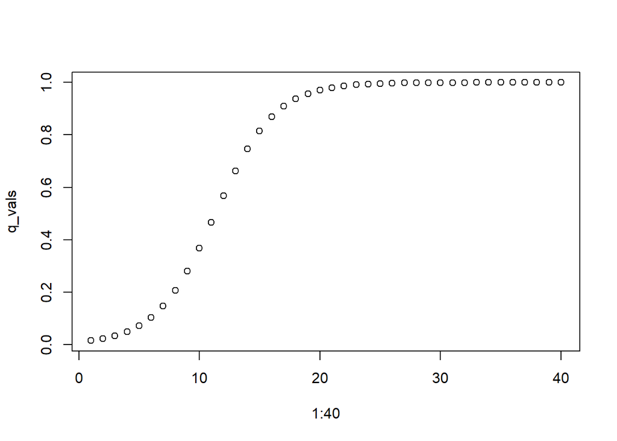

```r
plot(1:40, q_vals)
```

Repeat the above experiment with $p=0.4$, $q=0.99$.

```r
p=0.4
q=0.99
q_vals=c()
for(i in 1:40){
  q=bayes(p,q)
  q_vals = c(q_vals, q)
}
q_vals
```

```
##  [1] 9.850746e-01 9.777778e-01 9.670330e-01 9.513514e-01 9.287599e-01
##  [6] 8.968153e-01 8.528165e-01 7.943583e-01 7.202967e-01 6.319215e-01
## [11] 5.336997e-01 4.327938e-01 3.371711e-01 2.532427e-01 1.843940e-01
## [16] 1.309800e-01 9.130641e-02 6.278173e-02 4.274911e-02 2.891138e-02
## [21] 1.946181e-02 1.305926e-02 8.744238e-03 5.846533e-03 3.905300e-03
## [26] 2.606927e-03 1.739463e-03 1.160315e-03 7.738423e-04 5.160280e-04
## [31] 3.440778e-04 2.294115e-04 1.529527e-04 1.019737e-04 6.798477e-05
## [36] 4.532420e-05 3.021659e-05 2.014460e-05 1.342982e-05 8.953255e-06
```

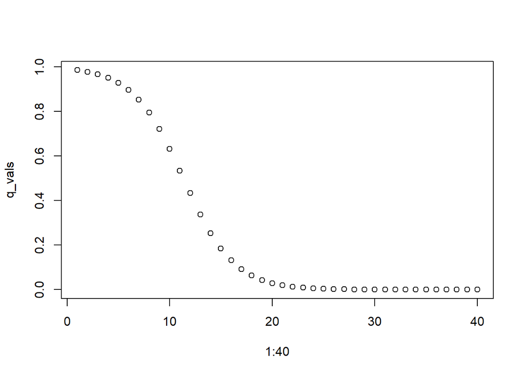

```r
plot(1:40, q_vals)
```

### 2.1.2 How many reliable Witnesses needed?

Suppose the police decide to arrest the Blue cab driver if $P(B|W) \ge 0.9$.

Suppose we intialize $p=0.6$ (witness reliability), $q=0.01$ (proportion of Blue cabs in the city), how many witnesses with reliability level $p$ would we need for the police to consider arresting the Blue cab? 17

You will need a counter variable initialized to zero and a while loop inside which you update $q$ using the bayes function, and update the counter by 1 at every iteration of the while loop.

```r
p=0.6
q=0.01
count=0;
while(q<0.9){
  q = bayes(p,q)
  count=count+1
}
count
```

```
## [1] 17
```

## 2.2 Working with two types of witnesses

In this problem we will work with two types of witnesses (1) reliable witnesses with fixed reliability level $p_1 > \frac{1}{2}$ and (2) unreliable witness with fixed reliability level $p_2 < \frac{1}{2}$.

### 2.2.1 Initial Plots

Initialize $p_1=0.6$, $p_2 = 0.45$, $q=0.01$, and q_vals = c(), the empty vector. Run a for loop (1 in 1:90) inside it, update q at every even iteration to $q = \text{bayes}(p_2,q)$, and at every odd iteration to $q = \text{bayes}(p_1,q)$ (You will need to use a “if” command), and finally concatanating the vector q_vals with the new value of q at every iteration.

```r
p_1=0.6
p_2=0.45
q=0.01
q_vals=c()
for(i in 1:90){
  if(i%%2==1){
    q= bayes(p_1, q)
    q_vals = c(q_vals, q)
  }
  if(i%%2==0){
  q = bayes(p_2,q)
    q_vals=c(q_vals, q)
  }
}
q_vals
```

```
##  [1] 0.01492537 0.01224490 0.01825558 0.01498612 0.02231200 0.01832963
##  [7] 0.02724475 0.02240213 0.03323098 0.02735426 0.04047776 0.03336371
## [13] 0.04922442 0.04063823 0.05974341 0.04941777 0.07233924 0.05997548
## [19] 0.08734397 0.07261645 0.10510838 0.08767325 0.12598704 0.10549689
## [25] 0.15031638 0.12644182 0.17838506 0.15084383 0.21039718 0.17899025
## [31] 0.24643100 0.21108307 0.28639775 0.24719759 0.33000781 0.28724128
## [37] 0.37675248 0.33092021 0.42590932 0.37772126 0.47657554 0.42691792
## [43] 0.52772850 0.47760430 0.57830579 0.52875614 0.62729197 0.57931110
## [49] 0.67379748 0.62825558 0.71711699 0.67470320 0.75676045 0.71795278
## [55] 0.79245613 0.75751871 0.82413081 0.79313354 0.85187499 0.82472770
## [61] 0.87590146 0.85239458 0.89650421 0.87634900 0.91402226 0.89688620
## [67] 0.92881060 0.91434577 0.94121890 0.92908278 0.95157718 0.94144663
## [73] 0.96018737 0.95176684 0.96731913 0.96034471 0.97320900 0.96744924
## [79] 0.97806145 0.97331631 0.98205123 0.97814976 0.98532630 0.98212377
## [85] 0.98801107 0.98538580 0.99020951 0.98805982 0.99200807 0.99024941
```

Construct a plot with x-axis 1:90 and y-axis q_vals.

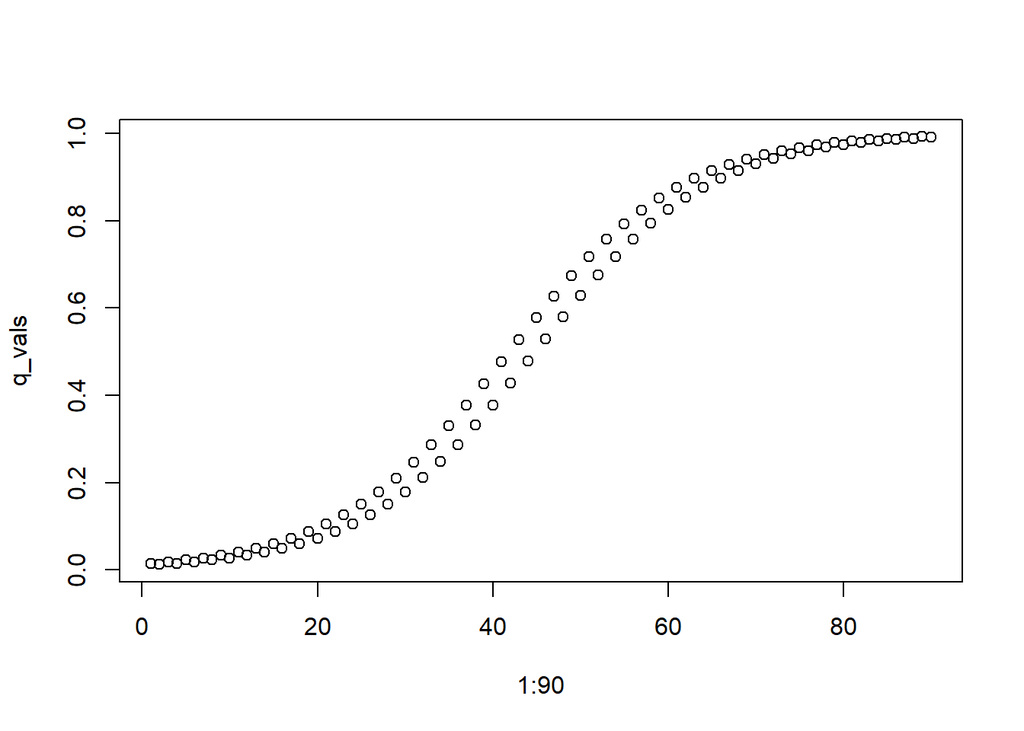

```r
plot(1:90, q_vals)
```

What do you notice? (Compared to case with single witness)

There are two visible trends that are flatter than the single witness curve, and it took about 4 times as many witnesses to get to P(B|W)=0.9

### 2.2.2 How many witnesses need?

Suppose the police decide to arrest the Blue cab driver if $P(B|W) \ge 0.9$.

Initialize $p_1=0.6$, $p_2 = 0.45$, $q=0.01$. How many witnesses will we have to have if we are going to sequentially work with one reliable witness followed by an unreliable witness? 68

```r
p_1=0.6
p_2=0.45
q=0.01
count =0
while(q<0.9){
  q = bayes(p_1,q)
  count=count+1
  q = bayes(p_2,q)
  count=count+1
}
count
```

```
## [1] 68
```

This problem can be generalized to choosing $p$ from any given probability distribution on $(0,1)$, we will be working with the Beta distribution later in the semester, which can be an interesting candidate to sample our values for $p$ (that is witness reliability).